# Time series - Li2Co3 zeroes calculations and statistics

```python
import numpy as np
import pandas as pd
import matplotlib.pyplot as plt
from statsmodels.graphics.tsaplots import plot_acf, plot_pacf
import statsmodels.api as sm
from tabulate import tabulate
from statsmodels.stats.diagnostic import acorr_ljungbox
from statsmodels.tsa.stattools import acf
from google.colab import files
from sklearn.metrics import mean_squared_error
```

# P1. Data Preprocess

```python
# Data from 2017-05-10 to 2024-04-19
li2co3 = pd.read_csv(r'/content/Lithium Carbonate 99%Min China Spot Historical Data (5).csv')
li2co3['Date'] = pd.to_datetime(li2co3['Date'])
# The date order need to be inverted (from early to late)
li2co3 = li2co3.sort_values('Date')
li2co3.set_index('Date', inplace=True)
li2co3 = pd.DataFrame(li2co3["Price"])


li2co3['Price'] = (li2co3['Price'].str.replace(",","").astype(float))
na_count = li2co3['Price'].isna().sum()
print("Number of missing values:", na_count)
if na_count > 0:
  li2co3 = li2co3.dropna(subset=['Price'])

# daily log returns
li2co3['log_ret'] = np.log(li2co3['Price']).diff()
li2co3 = li2co3.dropna(subset=['log_ret'])
```

```
Number of missing values: 0
```

```python
li2co3.head(10)
```

| Date | Price | log_ret |
| --- | --- | --- |
| 2017-05-11 | 123000.0 | 0.000000 |
| 2017-05-12 | 123000.0 | 0.000000 |
| 2017-05-15 | 123000.0 | 0.000000 |
| 2017-05-16 | 123000.0 | 0.000000 |
| 2017-05-17 | 123000.0 | 0.000000 |
| 2017-05-18 | 123000.0 | 0.000000 |
| 2017-05-19 | 124000.0 | 0.008097 |
| 2017-05-22 | 124000.0 | 0.000000 |
| 2017-05-23 | 124000.0 | 0.000000 |
| 2017-05-24 | 124000.0 | 0.000000 |

```python
li2co3.tail(10)
```

| Date | Price | log_ret |
| --- | --- | --- |
| 2024-04-08 | 109500.0 | 0.027780 |
| 2024-04-09 | 109500.0 | 0.000000 |
| 2024-04-10 | 110500.0 | 0.009091 |
| 2024-04-11 | 109500.0 | -0.009091 |
| 2024-04-12 | 109500.0 | 0.000000 |
| 2024-04-15 | 109500.0 | 0.000000 |
| 2024-04-16 | 109500.0 | 0.000000 |
| 2024-04-17 | 109500.0 | 0.000000 |
| 2024-04-18 | 109500.0 | 0.000000 |
| 2024-04-19 | 109500.0 | 0.000000 |

# P2. Weekly log return series and zero count series

```python
Fridays = pd.DataFrame()
Thursdays = pd.DataFrame()
Wednesdays = pd.DataFrame()
Tuesdays = pd.DataFrame()
Mondays = pd.DataFrame()
```

```python
def weekly_returns(data, chosen_day):
    # chosen_day = ['W-MON', 'W-TUE', 'W-WED', 'W-THU', 'W-FRI']
    weekly_log_return = data.groupby(pd.Grouper(freq=chosen_day))['log_ret'].sum()
    weekly_log_return = weekly_log_return.dropna()
    return weekly_log_return
```

```python
def count_zero(df, chosen_day):
    # chosen_day = ['Monday', 'Tuesday', 'Wednesday', 'Thursday', 'Friday']
    # Create a zero dummy series: 1 if 'log_ret' is zero, 0 otherwise
    data = df.copy()
    data['zero_dummy'] = (data['log_ret'] == 0).astype(int)
    # Compute the sum of past 22 days and past 5 days for zero_dummy
    data['zero_count_22'] = data['zero_dummy'].rolling(window=22).sum()
    data['zero_count_5'] = data['zero_dummy'].rolling(window=5).sum()
    data = data.dropna()
    # Extract chosen day
    data['day_of_week'] = data.index.day_name()
    chosendays_data = data[data['day_of_week'] == chosen_day]

    # Select only the zero count columns and the index for Fridays
    chosendays_data = chosendays_data[['zero_count_22', 'zero_count_5']]
    chosendays_data['zero_count_22'] = chosendays_data['zero_count_22'].astype(int)
    chosendays_data['zero_count_5'] = chosendays_data['zero_count_5'].astype(int)
    return chosendays_data
```

```python
# Friday to Friday
Fridays['Log_Return'] = weekly_returns(li2co3, 'W-FRI')
Fridays['Zero_Count_22'] = count_zero(li2co3, 'Friday')['zero_count_22']
Fridays['Zero_Count_5'] = count_zero(li2co3, 'Friday')['zero_count_5']
Fridays = Fridays.dropna()

# Thursday to Thursday
Thursdays['Log_Return'] = weekly_returns(li2co3, 'W-THU')
Thursdays['Zero_Count_22'] = count_zero(li2co3, 'Thursday')['zero_count_22']
Thursdays['Zero_Count_5'] = count_zero(li2co3, 'Thursday')['zero_count_5']
Thursdays = Thursdays.dropna()

# Wednesday to Wednesday
Wednesdays['Log_Return'] = weekly_returns(li2co3, 'W-WED')
Wednesdays['Zero_Count_22'] = count_zero(li2co3, 'Wednesday')['zero_count_22']
Wednesdays['Zero_Count_5'] = count_zero(li2co3, 'Wednesday')['zero_count_5']
Wednesdays = Wednesdays.dropna()

# Tuesday to Tuesday
Tuesdays['Log_Return'] = weekly_returns(li2co3, 'W-TUE')
Tuesdays['Zero_Count_22'] = count_zero(li2co3, 'Tuesday')['zero_count_22']
Tuesdays['Zero_Count_5'] = count_zero(li2co3, 'Tuesday')['zero_count_5']
Tuesdays = Tuesdays.dropna()

# Monday to Monday
Mondays['Log_Return'] = weekly_returns(li2co3, 'W-MON')
Mondays['Zero_Count_22'] = count_zero(li2co3, 'Monday')['zero_count_22']
Mondays['Zero_Count_5'] = count_zero(li2co3, 'Monday')['zero_count_5']
Mondays = Mondays.dropna()
```

```python
print("Friday to Firday")
print(Fridays.tail(10))
print("Thursday to Thursday")
print(Thursdays.tail(10))
print("Wednesday to Wednesday")
print(Wednesdays.tail(10))
print("Tuesday to Tuesday")
print(Tuesdays.tail(10))
print("Monday to Monday")
print(Mondays.tail(10))
```

```
Friday to Firday
            Log_Return  Zero_Count_22  Zero_Count_5
Date
2024-01-26    0.000000           22.0           5.0
2024-02-02    0.000000           22.0           5.0
2024-02-23   -0.005666           20.0           4.0
2024-03-01    0.092206           16.0           1.0
2024-03-08    0.050516           14.0           3.0
2024-03-15    0.038652           10.0           0.0
2024-03-22    0.028039            8.0           2.0
2024-03-29   -0.037563            7.0           2.0
2024-04-12    0.027780            7.0           2.0
2024-04-19    0.000000           12.0           5.0
Thursday to Thursday
            Log_Return  Zero_Count_22  Zero_Count_5
Date
2024-01-25    0.000000           22.0           5.0
2024-02-01    0.000000           22.0           5.0
2024-02-22   -0.005666           20.0           4.0
2024-02-29    0.071263           17.0           2.0
2024-03-07    0.071459           14.0           2.0
2024-03-14    0.066691           10.0           1.0
2024-03-21    0.000000            8.0           1.0
2024-03-28   -0.037563            6.0           2.0
2024-04-11    0.027780            6.0           1.0
2024-04-18    0.000000           11.0           5.0
Wednesday to Wednesday
            Log_Return  Zero_Count_22  Zero_Count_5
Date
2024-02-07    0.022858           21.0           4.0
2024-02-21   -0.005666           20.0           4.0
2024-02-28    0.039002           18.0           3.0
2024-03-06    0.103720           14.0           1.0
2024-03-13    0.057432           11.0           2.0
2024-03-20    0.000000            8.0           1.0
2024-03-27   -0.028304            5.0           1.0
2024-04-03    0.018958            8.0           3.0
2024-04-10    0.036871            7.0           1.0
2024-04-17   -0.009091           10.0           4.0
Tuesday to Tuesday
```

[output cut: 10 more lines]

```
2024-04-09    0.037214            8.0           2.0
2024-04-16    0.000000            9.0           3.0
Monday to Monday
            Log_Return  Zero_Count_22  Zero_Count_5
Date
2024-02-05    0.022858           21.0           4.0
2024-02-19    0.000000           21.0           4.0
2024-02-26   -0.005666           20.0           4.0
2024-03-04    0.122821           15.0           0.0
2024-03-11    0.029705           13.0           3.0
2024-03-18    0.038282            9.0           0.0
2024-03-25    0.009346            7.0           2.0
2024-04-01   -0.028304            8.0           3.0
2024-04-08    0.046737            8.0           2.0
2024-04-15    0.000000            8.0           3.0
```

# P3. Summary statistics

```python
summary_statistics_Fridays = Fridays.describe().loc[['mean', 'min', 'max', 'std']]
summary_statistics_Thursdays = Thursdays.describe().loc[['mean', 'min', 'max', 'std']]
summary_statistics_Wednesdays = Wednesdays.describe().loc[['mean', 'min', 'max', 'std']]
summary_statistics_Tuesdays = Tuesdays.describe().loc[['mean', 'min', 'max', 'std']]
summary_statistics_Mondays = Mondays.describe().loc[['mean', 'min', 'max', 'std']]

print("Friday to Firday")
print(summary_statistics_Fridays)
print("Thursday to Thursday")
print(summary_statistics_Thursdays)
print("Wednesday to Wednesday")
print(summary_statistics_Wednesdays)
print("Tuesday to Tuesday")
print(summary_statistics_Tuesdays)
print("Monday to Monday")
print(summary_statistics_Mondays)
```

```
Friday to Firday
      Log_Return  Zero_Count_22  Zero_Count_5
mean   -0.000397      15.089783      3.421053
min    -0.152469       0.000000      0.000000
max     0.267022      22.000000      5.000000
std     0.044616       5.608998      1.584804
Thursday to Thursday
      Log_Return  Zero_Count_22  Zero_Count_5
mean   -0.000692      15.096386      3.418675
min    -0.172141       0.000000      0.000000
max     0.204501      22.000000      5.000000
std     0.044082       5.556335      1.576646
Wednesday to Wednesday
      Log_Return  Zero_Count_22  Zero_Count_5
mean   -0.000154      15.036145      3.418675
min    -0.190575       0.000000      0.000000
max     0.252326      22.000000      5.000000
std     0.044743       5.529806      1.533911
Tuesday to Tuesday
      Log_Return  Zero_Count_22  Zero_Count_5
mean   -0.000803      15.026946      3.410180
min    -0.163827       0.000000      0.000000
max     0.298955      22.000000      5.000000
std     0.045178       5.532529      1.552684
Monday to Monday
      Log_Return  Zero_Count_22  Zero_Count_5
mean   -0.000810      15.090062      3.403727
min    -0.171980       0.000000      0.000000
max     0.293305      22.000000      5.000000
std     0.045656       5.598839      1.576221
```

# P4. Autocorrelogram and partial autocorrelogram for daily return

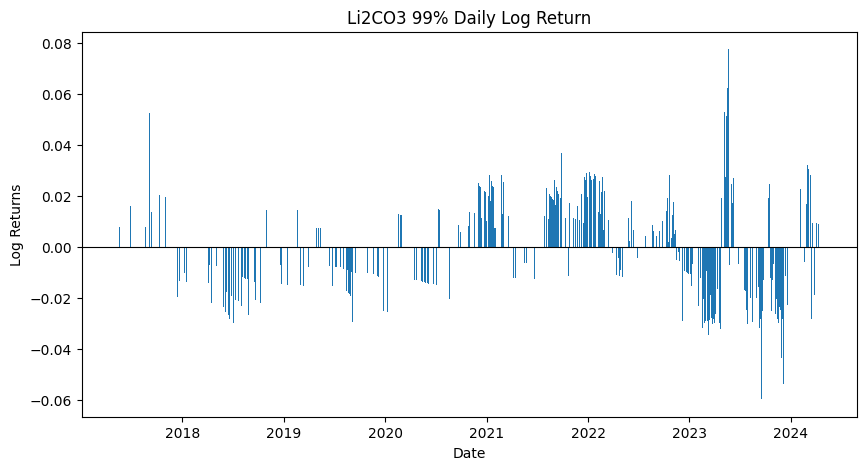

[figure not shown]

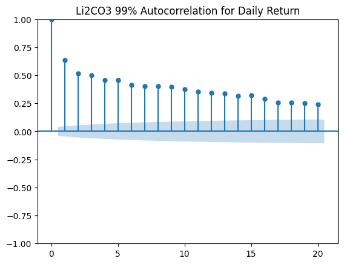

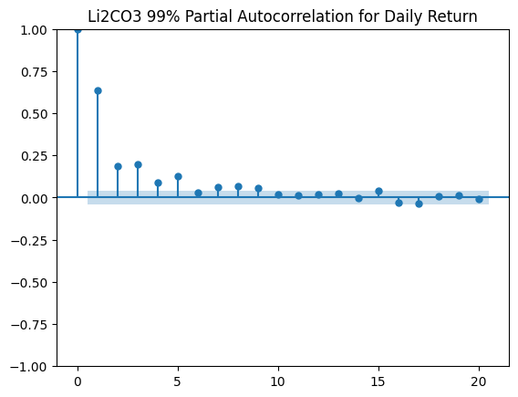

```python
# Daily return
fig, axs = plt.subplots(1, 1, figsize=(10, 5))
axs.bar(li2co3.index, li2co3['log_ret'], width=2.5)
plt.axhline(0, linewidth=0.8, color='k')
plt.xlabel('Date')
plt.ylabel('Log Returns')
plt.title('Li2CO3 99% Daily Log Return')
plt.show()

# Plot autocorrelation and partial autocorrelation
plot_acf(li2co3['log_ret'], lags=20, alpha=0.1, title='Li2CO3 99% Autocorrelation for Daily Return')
plot_pacf(li2co3['log_ret'], lags=20, alpha=0.1, method='ywm', title='Li2CO3 99% Partial Autocorrelation for Daily Return')
```

# P5. Autocorrelogram and partial autocorrelogram for weekly return

```python
def plot_returns_acf_pacf(df, df_name):
    """
    Plots the log returns, autocorrelation, and partial autocorrelation for a given DataFrame.

    Parameters:
    - df: The DataFrame containing the log returns data.
    - df_name: Name of the DataFrame to use in plot titles to indicate the data source.
    """
    data = df.copy()

    # Plotting the log returns
    fig, axs = plt.subplots(1, 1, figsize=(10, 5))
    axs.bar(data.index, data['Log_Return'], width=2.5)
    plt.axhline(0, linewidth=0.8, color='k')
    plt.xlabel('Date')
    plt.ylabel('Log Returns')
    plt.title(f'Li2CO3 99% {df_name} Weekly Log Return')
    plt.show()

    # Plotting the autocorrelation
    fig_acf = plot_acf(data['Log_Return'], lags=20, alpha=0.1, title=f'Autocorrelation for {df_name} Weekly Return')

    # Plotting the partial autocorrelation
    fig_pacf = plot_pacf(data['Log_Return'], lags=20, alpha=0.1, method='ywm', title=f'Partial Autocorrelation for {df_name} Weekly Return')
    plt.show()
```

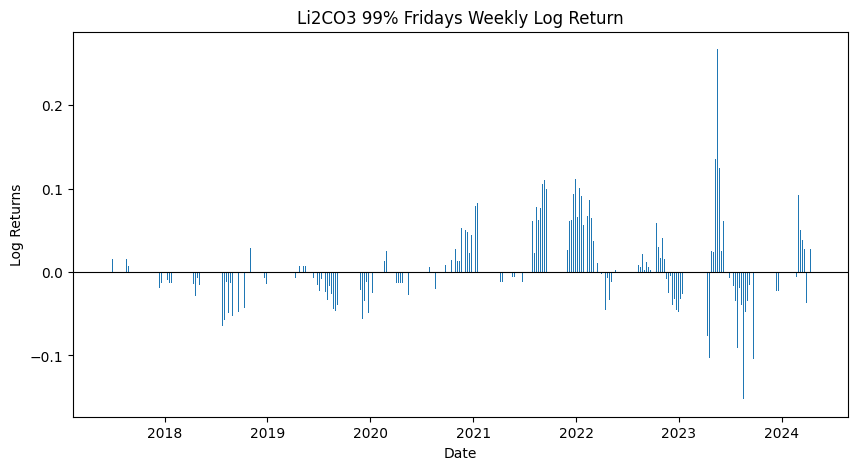

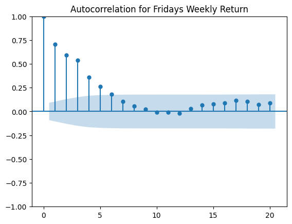

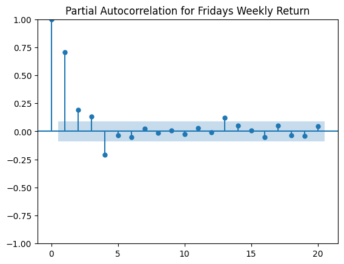

```python
# Fridays
plot_returns_acf_pacf(Fridays, 'Fridays')
```

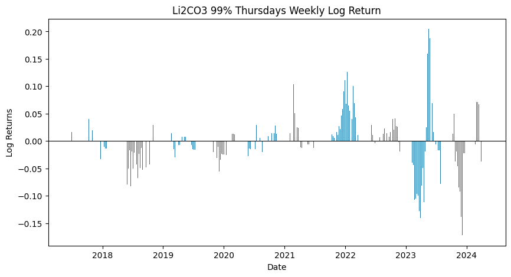

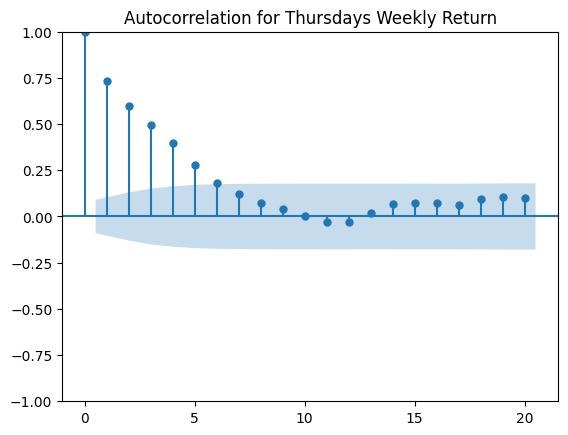

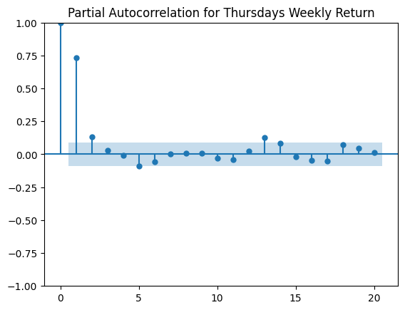

```python
# Thursdays
plot_returns_acf_pacf(Thursdays, 'Thursdays')
```

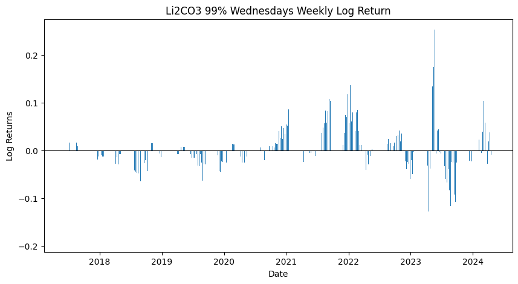

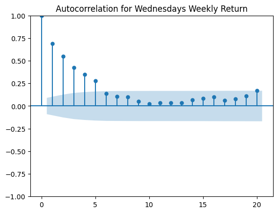

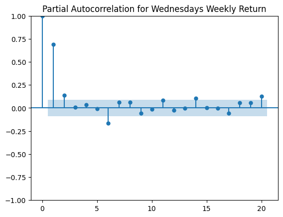

```python
# Wednesdays
plot_returns_acf_pacf(Wednesdays, 'Wednesdays')
```

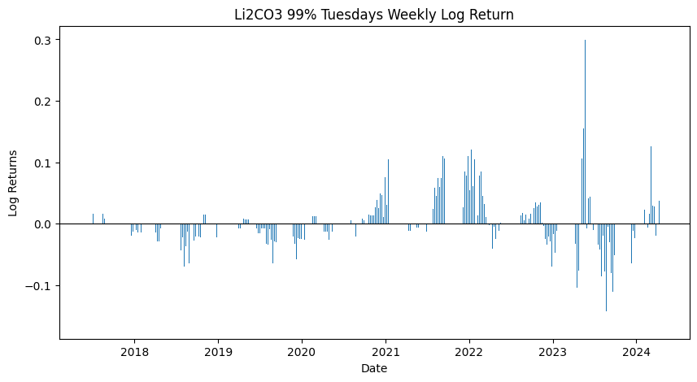

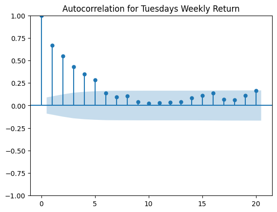

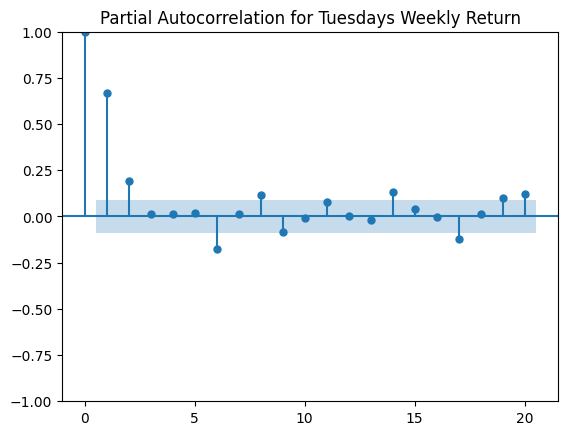

```python
# Tuesdays
plot_returns_acf_pacf(Tuesdays, 'Tuesdays')
```

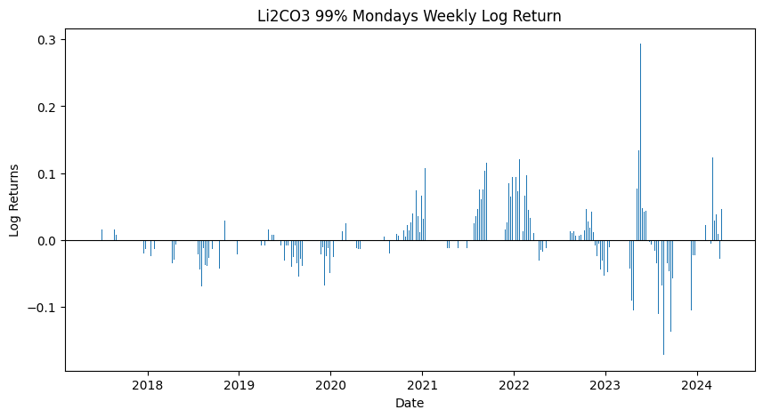

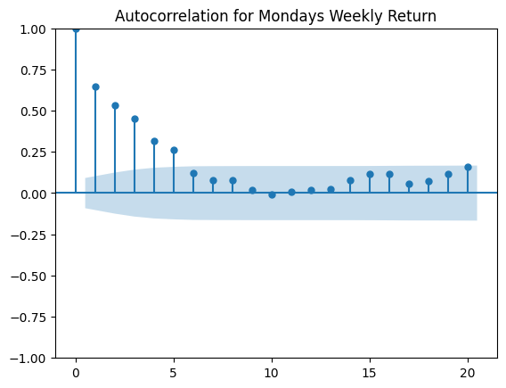

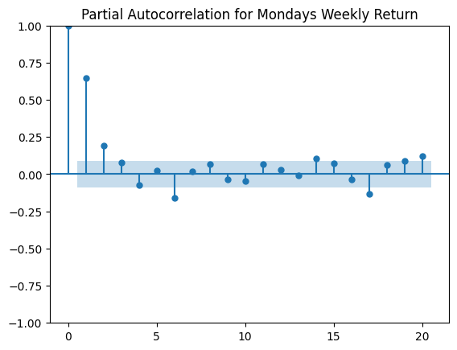

```python
# Mondays
plot_returns_acf_pacf(Mondays, 'Mondays')
```

maxlags = 4 for Fridays

maxlags = 2 for others

# P6. Two AR(2) models for daily return

```python
def estimate_ar2_model(df, lags):
    """
    Estimate a basic AR(2) model for returns.

    Parameters:
    - df: DataFrame containing the log returns series under 'log_ret'.
    - lags: Number of lags to use for HAC standard errors.

    Returns:
    - model: OLS regression results containing the fitted model.
    """

    data = df.copy()
    data['log_ret_lag1'] = data['log_ret'].shift(1)
    data['log_ret_lag2'] = data['log_ret'].shift(2)

    data.dropna(inplace=True)

    # Define the variables and add a constant term for the intercept (alpha)
    X = data[['log_ret_lag1', 'log_ret_lag2']]
    X = sm.add_constant(X)  # Adds a constant column to input data set
    Y = data['log_ret']

    # Fit the AR(2) model
    model = sm.OLS(Y, X).fit(cov_type='HAC', cov_kwds={'maxlags': lags})

    return model
```

```python
# lags=5 acording to the daily pacf
daily_return_ar2_model = estimate_ar2_model(li2co3, lags=5)
```

```python
print(daily_return_ar2_model.summary())
```

```
                            OLS Regression Results
==============================================================================
Dep. Variable:                log_ret   R-squared:                       0.424
Model:                            OLS   Adj. R-squared:                  0.423
Method:                 Least Squares   F-statistic:                     188.0
Date:                Mon, 03 Jun 2024   Prob (F-statistic):           2.62e-74
Time:                        17:03:54   Log-Likelihood:                 5540.0
No. Observations:                1662   AIC:                        -1.107e+04
Df Residuals:                    1659   BIC:                        -1.106e+04
Df Model:                           2
Covariance Type:                  HAC
================================================================================
                   coef    std err          z      P>|z|      [0.025      0.975]
--------------------------------------------------------------------------------
const        -2.075e-05      0.000     -0.104      0.917      -0.000       0.000
log_ret_lag1     0.5158      0.036     14.302      0.000       0.445       0.586
log_ret_lag2     0.1876      0.038      4.933      0.000       0.113       0.262
==============================================================================
Omnibus:                      177.765   Durbin-Watson:                   2.075
Prob(Omnibus):                  0.000   Jarque-Bera (JB):             1463.753
Skew:                          -0.004   Prob(JB):                         0.00
Kurtosis:                       7.598   Cond. No.                         145.
==============================================================================

Notes:
[1] Standard Errors are heteroscedasticity and autocorrelation robust (HAC) using 5 lags and without small sample correction
```

```python
def estimate_ar2_model_with_zero_dummy(df, lags):
    """
    Estimate an AR(2) model for log returns with modifications to account for zero dummies.

    Parameters:
    - df: DataFrame containing the log returns 'log_ret'.
    - lags: Number of lags to use for HAC standard errors.

    Returns:
    - model: OLS regression results containing the fitted model.
    """

    data = df.copy()
    data['zero_dummy'] = (data['log_ret'] == 0).astype(int)

    # Generate lagged return series
    data['log_ret_lag1'] = data['log_ret'].shift(1)
    data['log_ret_lag2'] = data['log_ret'].shift(2)

    # Generate interaction terms
    data['log_ret_lag1_zero'] = data['log_ret_lag1'] * data['zero_dummy']
    data['log_ret_lag2_zero'] = data['log_ret_lag2'] * data['zero_dummy']

    data.dropna(inplace=True)

    # Define the new model with additional interaction terms
    X = data[['zero_dummy', 'log_ret_lag1', 'log_ret_lag2', 'log_ret_lag1_zero', 'log_ret_lag2_zero']]
    X = sm.add_constant(X)
    Y = data['log_ret']

    # Fit the AR(2) model
    model = sm.OLS(Y, X).fit(cov_type='HAC', cov_kwds={'maxlags': lags})

    return model
```

```python
# lags=5 acording to the daily pacf
daily_return_ar2_model_with_zero_dummy = estimate_ar2_model_with_zero_dummy(li2co3, lags = 5)
```

```python
print(daily_return_ar2_model_with_zero_dummy.summary())
```

```
                            OLS Regression Results
==============================================================================
Dep. Variable:                log_ret   R-squared:                       0.607
Model:                            OLS   Adj. R-squared:                  0.605
Method:                 Least Squares   F-statistic:                     442.3
Date:                Mon, 03 Jun 2024   Prob (F-statistic):          5.35e-211
Time:                        17:04:00   Log-Likelihood:                 5856.5
No. Observations:                1662   AIC:                        -1.170e+04
Df Residuals:                    1656   BIC:                        -1.167e+04
Df Model:                           5
Covariance Type:                  HAC
=====================================================================================
                        coef    std err          z      P>|z|      [0.025      0.975]
-------------------------------------------------------------------------------------
const                -0.0010      0.001     -1.594      0.111      -0.002       0.000
zero_dummy            0.0010      0.001      1.594      0.111      -0.000       0.002
log_ret_lag1          0.6606      0.045     14.796      0.000       0.573       0.748
log_ret_lag2          0.3622      0.048      7.575      0.000       0.268       0.456
log_ret_lag1_zero    -0.6606      0.045    -14.796      0.000      -0.748      -0.573
log_ret_lag2_zero    -0.3622      0.048     -7.575      0.000      -0.456      -0.268
==============================================================================
Omnibus:                      304.524   Durbin-Watson:                   1.918
Prob(Omnibus):                  0.000   Jarque-Bera (JB):             5065.128
Skew:                           0.339   Prob(JB):                         0.00
Kurtosis:                      11.526   Cond. No.                         413.
==============================================================================

Notes:
[1] Standard Errors are heteroscedasticity and autocorrelation robust (HAC) using 5 lags and without small sample correction
```

# P7. Four AR(2) models for returns with zero count series (use Fridays as example)

## Model1: Standard AR(2) model

```python
def estimate_ar2_model(df, lags):
    """
    Estimate a basic AR(2) model for returns.

    Parameters:
    - df: DataFrame containing the log returns series under 'Log_Return'.
    - lags: Number of lags to use for HAC standard errors.

    Returns:
    - model: OLS regression results containing the fitted model.
    """

    data = df.copy()
    data['log_ret_lag1'] = data['Log_Return'].shift(1)
    data['log_ret_lag2'] = data['Log_Return'].shift(2)

    data.dropna(inplace=True)

    # Define the variables and add a constant term for the intercept (alpha)
    X = data[['log_ret_lag1', 'log_ret_lag2']]
    X = sm.add_constant(X)  # Adds a constant column to input data set
    Y = data['Log_Return']

    # Fit the AR(2) model
    model = sm.OLS(Y, X).fit(cov_type='HAC', cov_kwds={'maxlags': lags})

    return model
```

```python
# lags=4 acording to the weekly pacf
weekly_return_ar2_model = estimate_ar2_model(Fridays, lags=4)

print(weekly_return_ar2_model.summary())
```

```
                            OLS Regression Results
==============================================================================
Dep. Variable:             Log_Return   R-squared:                       0.516
Model:                            OLS   Adj. R-squared:                  0.513
Method:                 Least Squares   F-statistic:                     84.51
Date:                Mon, 03 Jun 2024   Prob (F-statistic):           3.69e-30
Time:                        17:04:06   Log-Likelihood:                 658.66
No. Observations:                 321   AIC:                            -1311.
Df Residuals:                     318   BIC:                            -1300.
Df Model:                           2
Covariance Type:                  HAC
================================================================================
                   coef    std err          z      P>|z|      [0.025      0.975]
--------------------------------------------------------------------------------
const        -7.831e-05      0.002     -0.044      0.965      -0.004       0.003
log_ret_lag1     0.5691      0.079      7.160      0.000       0.413       0.725
log_ret_lag2     0.1929      0.088      2.188      0.029       0.020       0.366
==============================================================================
Omnibus:                       73.893   Durbin-Watson:                   2.050
Prob(Omnibus):                  0.000   Jarque-Bera (JB):              539.301
Skew:                           0.713   Prob(JB):                    7.80e-118
Kurtosis:                       9.188   Cond. No.                         41.3
==============================================================================

Notes:
[1] Standard Errors are heteroscedasticity and autocorrelation robust (HAC) using 4 lags and without small sample correction
```

## Model2: AR(2) model using interaction with the weekly zero count series

```python
def estimate_ar2_model_with_weekly_zero(df, lags):
    """
    Estimate an AR(2) model for weekly log returns, incorporating
    weekly zero count series as interaction effect,
    and allowing for specification of lags for HAC standard errors.

    Parameters:
    - df: DataFrame containing the weekly log returns under 'Log_Return',
        and the weekly zero count series 'Zero_Count_5'.
    - lags: Maximum number of lags to use for HAC standard errors.

    Returns:
    - model: OLS regression results containing the fitted model with HAC standard errors.
    """

    data = df.copy()
    # Generate lagged return series
    data['Log_Return_Lag1'] = data['Log_Return'].shift(1)
    data['Log_Return_Lag2'] = data['Log_Return'].shift(2)

    # Generate interaction terms for lagged returns and 'Zero_Count_5'
    data['Log_Return_Lag1_Zero5'] = data['Log_Return_Lag1'] * data['Zero_Count_5']
    data['Log_Return_Lag2_Zero5'] = data['Log_Return_Lag2'] * data['Zero_Count_5']

    # Drop any rows with NaN values that were created by lagging
    data.dropna(inplace=True)

    # Define the model with additional interaction terms
    X = data[['Zero_Count_5', 'Log_Return_Lag1', 'Log_Return_Lag2',
              'Log_Return_Lag1_Zero5', 'Log_Return_Lag2_Zero5']]
    X = sm.add_constant(X)
    Y = data['Log_Return']

    # Fit the model with HAC standard errors
    model = sm.OLS(Y, X).fit(cov_type='HAC', cov_kwds={'maxlags': lags})

    return model
```

```python
# lags=4 acording to the weekly pacf
ar2_model_with_weekly_zero = estimate_ar2_model_with_weekly_zero(Fridays, lags=4)

print(ar2_model_with_weekly_zero.summary())
```

```
                            OLS Regression Results
==============================================================================
Dep. Variable:             Log_Return   R-squared:                       0.656
Model:                            OLS   Adj. R-squared:                  0.650
Method:                 Least Squares   F-statistic:                     61.77
Date:                Mon, 03 Jun 2024   Prob (F-statistic):           9.64e-45
Time:                        17:04:12   Log-Likelihood:                 713.29
No. Observations:                 321   AIC:                            -1415.
Df Residuals:                     315   BIC:                            -1392.
Df Model:                           5
Covariance Type:                  HAC
=========================================================================================
                            coef    std err          z      P>|z|      [0.025      0.975]
-----------------------------------------------------------------------------------------
const                    -0.0015      0.007     -0.202      0.840      -0.016       0.013
Zero_Count_5           6.781e-05      0.002      0.041      0.967      -0.003       0.003
Log_Return_Lag1           0.9768      0.188      5.203      0.000       0.609       1.345
Log_Return_Lag2           0.3009      0.179      1.680      0.093      -0.050       0.652
Log_Return_Lag1_Zero5    -0.2143      0.058     -3.664      0.000      -0.329      -0.100
Log_Return_Lag2_Zero5    -0.0485      0.047     -1.022      0.307      -0.141       0.045
==============================================================================
Omnibus:                       88.859   Durbin-Watson:                   1.738
Prob(Omnibus):                  0.000   Jarque-Bera (JB):              614.566
Skew:                           0.938   Prob(JB):                    3.54e-134
Kurtosis:                       9.514   Cond. No.                         340.
==============================================================================

Notes:
[1] Standard Errors are heteroscedasticity and autocorrelation robust (HAC) using 4 lags and without small sample correction
```

## Model3: AR(2) model using interaction with the monthly zero count series

```python
def estimate_ar2_model_with_monthly_zero(df, lags):
    """
    Estimate an AR(2) model for weekly log returns, incorporating
    monthly zero count series as interaction effect,
    and allowing for specification of lags for HAC standard errors.

    Parameters:
    - df: DataFrame containing the weekly log returns under 'Log_Return',
        and the monthly zero count series 'Zero_Count_22'.
    - lags: Maximum number of lags to use for HAC standard errors.

    Returns:
    - model: OLS regression results containing the fitted model with HAC standard errors.
    """

    data = df.copy()
    # Generate lagged return series
    data['Log_Return_Lag1'] = data['Log_Return'].shift(1)
    data['Log_Return_Lag2'] = data['Log_Return'].shift(2)

    # Generate interaction terms for lagged returns and 'Zero_Count_22'
    data['Log_Return_Lag1_Zero22'] = data['Log_Return_Lag1'] * data['Zero_Count_22']
    data['Log_Return_Lag2_Zero22'] = data['Log_Return_Lag2'] * data['Zero_Count_22']

    # Drop any rows with NaN values that were created by lagging
    data.dropna(inplace=True)

    # Define the model with additional interaction terms
    X = data[['Zero_Count_22', 'Log_Return_Lag1', 'Log_Return_Lag2',
              'Log_Return_Lag1_Zero22', 'Log_Return_Lag2_Zero22']]
    X = sm.add_constant(X)
    Y = data['Log_Return']

    # Fit the model with HAC standard errors
    model = sm.OLS(Y, X).fit(cov_type='HAC', cov_kwds={'maxlags': lags})

    return model
```

```python
# lags=4 acording to the weekly pacf
ar2_model_with_monthly_zero = estimate_ar2_model_with_monthly_zero(Fridays, lags=4)

print(ar2_model_with_monthly_zero.summary())
```

```
                            OLS Regression Results
==============================================================================
Dep. Variable:             Log_Return   R-squared:                       0.540
Model:                            OLS   Adj. R-squared:                  0.533
Method:                 Least Squares   F-statistic:                     43.84
Date:                Mon, 03 Jun 2024   Prob (F-statistic):           2.99e-34
Time:                        17:04:17   Log-Likelihood:                 666.79
No. Observations:                 321   AIC:                            -1322.
Df Residuals:                     315   BIC:                            -1299.
Df Model:                           5
Covariance Type:                  HAC
==========================================================================================
                             coef    std err          z      P>|z|      [0.025      0.975]
------------------------------------------------------------------------------------------
const                      0.0009      0.008      0.122      0.903      -0.014       0.016
Zero_Count_22             -0.0001      0.000     -0.266      0.790      -0.001       0.001
Log_Return_Lag1            0.9183      0.177      5.179      0.000       0.571       1.266
Log_Return_Lag2            0.0360      0.206      0.175      0.861      -0.368       0.440
Log_Return_Lag1_Zero22    -0.0396      0.013     -3.042      0.002      -0.065      -0.014
Log_Return_Lag2_Zero22     0.0109      0.014      0.766      0.444      -0.017       0.039
==============================================================================
Omnibus:                       62.191   Durbin-Watson:                   1.967
Prob(Omnibus):                  0.000   Jarque-Bera (JB):              422.402
Skew:                           0.568   Prob(JB):                     1.89e-92
Kurtosis:                       8.504   Cond. No.                     1.60e+03
==============================================================================

Notes:
[1] Standard Errors are heteroscedasticity and autocorrelation robust (HAC) using 4 lags and without small sample correction
[2] The condition number is large, 1.6e+03. This might indicate that there are
strong multicollinearity or other numerical problems.
```

## Model4: AR(2) model **separately** using interactions with the short-term illiquidity and long-term illiquidity variable

```python
def estimate_ar2_model_separate_illiquidity(df, lags):
    """
    Estimate a complex AR(2) model for log returns, incorporating
    separate interactions with two types of zero counts.
    The formula incorporates separate interactions for different lags
    with different term-length zero count measures.

    Parameters:
    - df: DataFrame containing the log returns under 'Log_Return',
        two zero count series 'Zero_Count_5' and 'Zero_Count_22'.
    - lags: Maximum number of lags to use for HAC standard errors.

    Returns:
    - model: OLS regression results containing the fitted model with HAC standard errors.
    """

    data = df.copy()
    # Generate lagged return series
    data['Log_Return_Lag1'] = data['Log_Return'].shift(1)
    data['Log_Return_Lag2'] = data['Log_Return'].shift(2)

    # Generate separate interaction terms for lagged returns and zero counts
    data['Log_Return_Lag1_Zero5'] = data['Log_Return_Lag1'] * data['Zero_Count_5']
    data['Log_Return_Lag2_Zero22'] = data['Log_Return_Lag2'] * data['Zero_Count_22']

    # Drop any rows with NaN values that were created by lagging
    data.dropna(inplace=True)

    # Define the model with additional interaction terms
    X = data[['Zero_Count_5', 'Zero_Count_22', 'Log_Return_Lag1', 'Log_Return_Lag2',
              'Log_Return_Lag1_Zero5', 'Log_Return_Lag2_Zero22']]
    X = sm.add_constant(X)
    Y = data['Log_Return']

    # Fit the model with HAC standard errors
    model = sm.OLS(Y, X).fit(cov_type='HAC', cov_kwds={'maxlags': lags})

    return model
```

```python
# lags=4 acording to the weekly pacf
ar2_model_with_separate_illiquidity = estimate_ar2_model_separate_illiquidity(Fridays, lags=4)

print(ar2_model_with_separate_illiquidity.summary())
```

```
                            OLS Regression Results
==============================================================================
Dep. Variable:             Log_Return   R-squared:                       0.665
Model:                            OLS   Adj. R-squared:                  0.659
Method:                 Least Squares   F-statistic:                     89.29
Date:                Mon, 03 Jun 2024   Prob (F-statistic):           6.64e-65
Time:                        17:04:21   Log-Likelihood:                 717.72
No. Observations:                 321   AIC:                            -1421.
Df Residuals:                     314   BIC:                            -1395.
Df Model:                           6
Covariance Type:                  HAC
==========================================================================================
                             coef    std err          z      P>|z|      [0.025      0.975]
------------------------------------------------------------------------------------------
const                     -0.0006      0.006     -0.089      0.929      -0.013       0.012
Zero_Count_5               0.0010      0.002      0.410      0.682      -0.004       0.006
Zero_Count_22             -0.0003      0.001     -0.447      0.655      -0.001       0.001
Log_Return_Lag1            1.2167      0.127      9.596      0.000       0.968       1.465
Log_Return_Lag2           -0.1038      0.133     -0.782      0.434      -0.364       0.156
Log_Return_Lag1_Zero5     -0.2886      0.036     -8.052      0.000      -0.359      -0.218
Log_Return_Lag2_Zero22     0.0286      0.011      2.618      0.009       0.007       0.050
==============================================================================
Omnibus:                       87.066   Durbin-Watson:                   1.952
Prob(Omnibus):                  0.000   Jarque-Bera (JB):              525.799
Skew:                           0.960   Prob(JB):                    6.67e-115
Kurtosis:                       8.969   Cond. No.                     1.27e+03
==============================================================================

Notes:
[1] Standard Errors are heteroscedasticity and autocorrelation robust (HAC) using 4 lags and without small sample correction
[2] The condition number is large, 1.27e+03. This might indicate that there are
strong multicollinearity or other numerical problems.
```

## Comparsion among last three models

```python
model1_results = ar2_model_with_weekly_zero
model2_results = ar2_model_with_monthly_zero
model3_results = ar2_model_with_separate_illiquidity

# Create a DataFrame to summarize the fit statistics
summary_stats = pd.DataFrame({
    'Model': ['Model with Weekly Zero', 'Model with Monthly Zero', 'Model with Separate Illiquidity'],
    'R-squared': [model1_results.rsquared, model2_results.rsquared, model3_results.rsquared],
    'Adj. R-squared': [model1_results.rsquared_adj, model2_results.rsquared_adj, model3_results.rsquared_adj],
    'AIC': [model1_results.aic, model2_results.aic, model3_results.aic],
    'BIC': [model1_results.bic, model2_results.bic, model3_results.bic],
    'F-statistic': [model1_results.fvalue, model2_results.fvalue, model3_results.fvalue]
})

# Print the summary statistics using tabulate
print(tabulate(summary_stats, headers='keys', tablefmt='pretty', showindex=False))
```

```
+---------------------------------+--------------------+--------------------+---------------------+---------------------+--------------------+
|              Model              |     R-squared      |   Adj. R-squared   |         AIC         |         BIC         |    F-statistic     |
+---------------------------------+--------------------+--------------------+---------------------+---------------------+--------------------+
|     Model with Weekly Zero      | 0.6555624644924585 | 0.6500952020240849 | -1414.5814877806774 | -1391.9528410418973 | 61.767219648707986 |
|     Model with Monthly Zero     | 0.5398221716814222 | 0.5325177617081115 | -1321.587709665845  | -1298.959062927065  | 43.83645709472929  |
| Model with Separate Illiquidity | 0.6649370501762542 | 0.6585345734280297 | -1421.4392679155076 | -1395.0391800535974 | 89.28868785518402  |
+---------------------------------+--------------------+--------------------+---------------------+---------------------+--------------------+
```

## Interpretation

**R-squared** & **Adj. R-squared**: The proportion of the variance in the dependent variable that is predictable from the independent variables. The higher these values, the better the model explains the variability of the response variable. From the table, the *Model with Separate Illiquidity* has both the highest R-squared and the highest Adjusted R-squared, which means it is the best model that explains the highest proportion of variance in the weekly log return series among the last three models.

**AIC** & **BIC**: Both criteria help in model selection where lower values generally indicate a better model. AIC shows the goodness of fit with a penalty for the number of parameters to avoid overfitting, and BIC considers a larger penalty for models with more parameters. The *Model with Separate Illiquidity* has both the lowest AIC and the lowest BIC, which means it is the best model from a complexity-fit trade-off perspective.

**F-statistic**: Indicates the overall significance of the regression AR(2) model. The higher the F-statistic, the more significant the model is. The *Model with Separate Illiquidity* has the highest F-statistic, which means it is statistically the most significant model in terms of the contribution of the explanatory variables used in the model.

## Conclusion

*Model with Separate Illiquidity* has advantages on all three aspects: explaining the variance in the weekly log return; balance between model complexity and fit; and also, the prediction ability, because the statistical significance of this model's explanatory variables is highest, making it potentially more reliable when making predictions or inferences.

Besides, *Model with Weekly Zero* is the second best model, where its variance explaining ability and complexity-fit balance are all very close to the *Model with Separate Illiquidity*.

The conclusion is just for Friday to Friday return series, it might be different for other days.

# P8: Rescale zero count series to zero fraction series

```python
# Rescale the zero counts to be fractions of their respective periods
Fridays['Zero_Fraction_5'] = Fridays['Zero_Count_5'] / 5
Fridays['Zero_Fraction_22'] = Fridays['Zero_Count_22'] / 22

print(Fridays[['Zero_Count_5', 'Zero_Fraction_5', 'Zero_Count_22', 'Zero_Fraction_22']].head())
# Double check the range
print(Fridays[['Zero_Count_5', 'Zero_Fraction_5', 'Zero_Count_22', 'Zero_Fraction_22']].describe())
```

```
            Zero_Count_5  Zero_Fraction_5  Zero_Count_22  Zero_Fraction_22
Date
2017-06-16           5.0              1.0           21.0          0.954545
2017-06-23           5.0              1.0           22.0          1.000000
2017-06-30           4.0              0.8           21.0          0.954545
2017-07-07           5.0              1.0           21.0          0.954545
2017-07-14           5.0              1.0           21.0          0.954545
       Zero_Count_5  Zero_Fraction_5  Zero_Count_22  Zero_Fraction_22
count    323.000000       323.000000     323.000000        323.000000
mean       3.421053         0.684211      15.089783          0.685899
std        1.584804         0.316961       5.608998          0.254954
min        0.000000         0.000000       0.000000          0.000000
25%        2.000000         0.400000      11.500000          0.522727
50%        4.000000         0.800000      17.000000          0.772727
75%        5.000000         1.000000      20.000000          0.909091
max        5.000000         1.000000      22.000000          1.000000
```

```python
Thursdays['Zero_Fraction_5'] = Thursdays['Zero_Count_5'] / 5
Thursdays['Zero_Fraction_22'] = Thursdays['Zero_Count_22'] / 22
print(Thursdays[['Zero_Count_5', 'Zero_Fraction_5', 'Zero_Count_22', 'Zero_Fraction_22']].describe())

Wednesdays['Zero_Fraction_5'] = Wednesdays['Zero_Count_5'] / 5
Wednesdays['Zero_Fraction_22'] = Wednesdays['Zero_Count_22'] / 22
print(Wednesdays[['Zero_Count_5', 'Zero_Fraction_5', 'Zero_Count_22', 'Zero_Fraction_22']].describe())

Tuesdays['Zero_Fraction_5'] = Tuesdays['Zero_Count_5'] / 5
Tuesdays['Zero_Fraction_22'] = Tuesdays['Zero_Count_22'] / 22
print(Tuesdays[['Zero_Count_5', 'Zero_Fraction_5', 'Zero_Count_22', 'Zero_Fraction_22']].describe())

Mondays['Zero_Fraction_5'] = Mondays['Zero_Count_5'] / 5
Mondays['Zero_Fraction_22'] = Mondays['Zero_Count_22'] / 22
print(Mondays[['Zero_Count_5', 'Zero_Fraction_5', 'Zero_Count_22', 'Zero_Fraction_22']].describe())
```

```
       Zero_Count_5  Zero_Fraction_5  Zero_Count_22  Zero_Fraction_22
count    332.000000       332.000000     332.000000        332.000000
mean       3.418675         0.683735      15.096386          0.686199
std        1.576646         0.315329       5.556335          0.252561
min        0.000000         0.000000       0.000000          0.000000
25%        2.000000         0.400000      11.000000          0.500000
50%        4.000000         0.800000      17.000000          0.772727
75%        5.000000         1.000000      20.000000          0.909091
max        5.000000         1.000000      22.000000          1.000000
       Zero_Count_5  Zero_Fraction_5  Zero_Count_22  Zero_Fraction_22
count    332.000000       332.000000     332.000000        332.000000
mean       3.418675         0.683735      15.036145          0.683461
std        1.533911         0.306782       5.529806          0.251355
min        0.000000         0.000000       0.000000          0.000000
25%        2.000000         0.400000      11.000000          0.500000
50%        4.000000         0.800000      17.000000          0.772727
75%        5.000000         1.000000      20.000000          0.909091
max        5.000000         1.000000      22.000000          1.000000
       Zero_Count_5  Zero_Fraction_5  Zero_Count_22  Zero_Fraction_22
count    334.000000       334.000000     334.000000        334.000000
mean       3.410180         0.682036      15.026946          0.683043
std        1.552684         0.310537       5.532529          0.251479
min        0.000000         0.000000       0.000000          0.000000
25%        2.000000         0.400000      11.000000          0.500000
50%        4.000000         0.800000      17.000000          0.772727
75%        5.000000         1.000000      20.000000          0.909091
max        5.000000         1.000000      22.000000          1.000000
       Zero_Count_5  Zero_Fraction_5  Zero_Count_22  Zero_Fraction_22
count    322.000000       322.000000     322.000000        322.000000
mean       3.403727         0.680745      15.090062          0.685912
std        1.576221         0.315244       5.598839          0.254493
min        0.000000         0.000000       0.000000          0.000000
25%        2.250000         0.450000      11.000000          0.500000
50%        4.000000         0.800000      17.000000          0.772727
75%        5.000000         1.000000      20.000000          0.909091
max        5.000000         1.000000      22.000000          1.000000
```

```python
# Fridays
csv_filename = 'Fridays_return_zeros_data.csv'
Fridays.to_csv(csv_filename, index=True, header=True)
files.download(csv_filename)

# Thursdays
csv_filename = 'Thursdays_return_zeros_data.csv'
Thursdays.to_csv(csv_filename, index=True, header=True)
files.download(csv_filename)

# Wednesdays
csv_filename = 'Wednesdays_return_zeros_data.csv'
Wednesdays.to_csv(csv_filename, index=True, header=True)
files.download(csv_filename)

# Tuesdays
csv_filename = 'Tuesdays_return_zeros_data.csv'
Tuesdays.to_csv(csv_filename, index=True, header=True)
files.download(csv_filename)

# Mondays
csv_filename = 'Mondays_return_zeros_data.csv'
Mondays.to_csv(csv_filename, index=True, header=True)
files.download(csv_filename)
```

# P9: Ten new models with rescaled zero fraction series

## M1: Constant

```python
# lags have no meaning, just for uniforming the parameter structure with AR models to perpare for the model summary function, add lags will not affect the result
def estimate_model_constant(df, lags):
    data = df.copy()
    X = sm.add_constant(pd.Series(1, index=data.index))
    Y = data['Log_Return']
    model = sm.OLS(Y, X).fit()
    return model
```

## M2: Constant + z5(t-1)

```python
# lags have no meaning, just for uniforming the parameter structure with AR models to perpare for the model summary function, add lags will not affect the result
def estimate_model_constant_z5(df, lags):
    data = df.copy()
    data['Z5_Lag1'] = data['Zero_Fraction_5'].shift(1)
    data.dropna(inplace=True)
    X = sm.add_constant(data['Z5_Lag1'])  # Adding a constant
    Y = data['Log_Return']
    model = sm.OLS(Y, X).fit()
    return model
```

## M3: Constant + z22(t-1)

```python
# lags have no meaning, just for uniforming the parameter structure with AR models to perpare for the model summary function, add lags will not affect the result
def estimate_model_constant_z22(df, lags):
    data = df.copy()
    data['Z22_Lag1'] = data['Zero_Fraction_22'].shift(1)
    data.dropna(inplace=True)
    X = sm.add_constant(data['Z22_Lag1'])
    Y = data['Log_Return']
    model = sm.OLS(Y, X).fit()
    return model
```

## M4: AR(1)

```python
def estimate_model_ar1(df, lags):
    data = df.copy()
    data['Log_Return_Lag1'] = data['Log_Return'].shift(1)
    data.dropna(inplace=True)
    X = sm.add_constant(data['Log_Return_Lag1'])
    Y = data['Log_Return']
    model = sm.OLS(Y, X).fit(cov_type='HAC', cov_kwds={'maxlags': lags})
    return model
```

## M5: AR(2)

```python
def estimate_model_ar2(df, lags):
    data = df.copy()
    data['Log_Return_Lag1'] = data['Log_Return'].shift(1)
    data['Log_Return_Lag2'] = data['Log_Return'].shift(2)
    data.dropna(inplace=True)
    X = sm.add_constant(data[['Log_Return_Lag1', 'Log_Return_Lag2']])
    Y = data['Log_Return']
    model = sm.OLS(Y, X).fit(cov_type='HAC', cov_kwds={'maxlags': lags})
    return model
```

## M6: AR(1) with z5(t-1) interaction

```python
def estimate_model_ar1_z5_interaction(df, lags):
    data = df.copy()
    data['Log_Return_Lag1'] = data['Log_Return'].shift(1)
    data['Z5_Lag1'] = data['Zero_Fraction_5'].shift(1)
    data.dropna(inplace=True)
    data['Log_Return_Lag1_Zero5'] = data['Log_Return_Lag1'] * data['Z5_Lag1']
    X = sm.add_constant(data[['Z5_Lag1', 'Log_Return_Lag1', 'Log_Return_Lag1_Zero5']])
    Y = data['Log_Return']
    model = sm.OLS(Y, X).fit(cov_type='HAC', cov_kwds={'maxlags': lags})
    return model
```

## M7: AR(1) with z22(t-1) interaction

```python
def estimate_model_ar1_z22_interaction(df, lags):
    data = df.copy()
    data['Log_Return_Lag1'] = data['Log_Return'].shift(1)
    data['Z22_Lag1'] = data['Zero_Fraction_22'].shift(1)
    data.dropna(inplace=True)
    data['Log_Return_Lag1_Zero22'] = data['Log_Return_Lag1'] * data['Z22_Lag1']
    X = sm.add_constant(data[['Z22_Lag1', 'Log_Return_Lag1', 'Log_Return_Lag1_Zero22']])
    Y = data['Log_Return']
    model = sm.OLS(Y, X).fit(cov_type='HAC', cov_kwds={'maxlags': lags})
    return model
```

## M8: AR(2) with z5(t-1) interaction

```python
def estimate_model_ar2_z5_interaction(df, lags):
    """
    Estimate an AR(2) model for weekly log returns, incorporating
    weekly zero fraction series as interaction effect,
    and allowing for specification of lags for HAC standard errors.

    Parameters:
    - df: DataFrame containing the weekly log returns under 'Log_Return',
        and the weekly zero fraction series 'Zero_Fraction_5'.
    - lags: Maximum number of lags to use for HAC standard errors.

    Returns:
    - model: OLS regression results containing the fitted model with HAC standard errors.
    """

    data = df.copy()
    data['Log_Return_Lag1'] = data['Log_Return'].shift(1)
    data['Log_Return_Lag2'] = data['Log_Return'].shift(2)
    data['Z5_Lag1'] = data['Zero_Fraction_5'].shift(1)
    data.dropna(inplace=True)
    data['Log_Return_Lag1_Zero5'] = data['Log_Return_Lag1'] * data['Z5_Lag1']
    data['Log_Return_Lag2_Zero5'] = data['Log_Return_Lag2'] * data['Z5_Lag1']
    X = data[['Z5_Lag1', 'Log_Return_Lag1', 'Log_Return_Lag2',
              'Log_Return_Lag1_Zero5', 'Log_Return_Lag2_Zero5']]
    X = sm.add_constant(X)
    Y = data['Log_Return']
    model = sm.OLS(Y, X).fit(cov_type='HAC', cov_kwds={'maxlags': lags})
    return model
```

## M9: AR(2) with z22(t-1) interaction

```python
def estimate_model_ar2_z22_interaction(df, lags):
    """
    Estimate an AR(2) model for weekly log returns, incorporating
    monthly zero fraction series as interaction effect,
    and allowing for specification of lags for HAC standard errors.

    Parameters:
    - df: DataFrame containing the weekly log returns under 'Log_Return',
        and the monthly zero fraction series 'Zero_Fraction_22'.
    - lags: Maximum number of lags to use for HAC standard errors.

    Returns:
    - model: OLS regression results containing the fitted model with HAC standard errors.
    """

    data = df.copy()
    data['Log_Return_Lag1'] = data['Log_Return'].shift(1)
    data['Log_Return_Lag2'] = data['Log_Return'].shift(2)
    data['Z22_Lag1'] = data['Zero_Fraction_22'].shift(1)
    data.dropna(inplace=True)
    data['Log_Return_Lag1_Zero22'] = data['Log_Return_Lag1'] * data['Z22_Lag1']
    data['Log_Return_Lag2_Zero22'] = data['Log_Return_Lag2'] * data['Z22_Lag1']
    X = data[['Z22_Lag1', 'Log_Return_Lag1', 'Log_Return_Lag2',
              'Log_Return_Lag1_Zero22', 'Log_Return_Lag2_Zero22']]
    X = sm.add_constant(X)
    Y = data['Log_Return']
    model = sm.OLS(Y, X).fit(cov_type='HAC', cov_kwds={'maxlags': lags})
    return model
```

## M10: AR(2) with z5(t-1) interaction for first lag and z22(t-1) for second lag

```python
def estimate_model_ar2_z5_z22_separate_interaction(df, lags):
    """
    Estimate an AR(2) model for weekly log returns, incorporating
    weekly and monthly zero fraction series as interaction effect,
    and allowing for specification of lags for HAC standard errors.

    Parameters:
    - df: DataFrame containing the weekly log returns under 'Log_Return',
        and two zero fraction series 'Zero_Fraction_22' and 'Zero_Fraction_5'.
    - lags: Maximum number of lags to use for HAC standard errors.

    Returns:
    - model: OLS regression results containing the fitted model with HAC standard errors.
    """
    data = df.copy()
    data['Log_Return_Lag1'] = data['Log_Return'].shift(1)
    data['Log_Return_Lag2'] = data['Log_Return'].shift(2)
    data['Z5_Lag1'] = data['Zero_Fraction_5'].shift(1)
    data['Z22_Lag1'] = data['Zero_Fraction_22'].shift(1)
    data.dropna(inplace=True)
    data['Log_Return_Lag1_Zero5'] = data['Log_Return_Lag1'] * data['Z5_Lag1']
    data['Log_Return_Lag2_Zero22'] = data['Log_Return_Lag2'] * data['Z22_Lag1']
    X = data[['Z5_Lag1', 'Z22_Lag1', 'Log_Return_Lag1', 'Log_Return_Lag2',
              'Log_Return_Lag1_Zero5', 'Log_Return_Lag2_Zero22']]
    X = sm.add_constant(X)
    Y = data['Log_Return']
    model = sm.OLS(Y, X).fit(cov_type='HAC', cov_kwds={'maxlags': lags})
    return model
```

```python
# Ten Model functions mapped to their descriptive names
models = [('Model with Only Constant', estimate_model_constant),
      ('Model with Weekly Zero', estimate_model_constant_z5),
      ('Model with Monthly Zero', estimate_model_constant_z22),
      ('AR(1)', estimate_model_ar1),
      ('AR(2)', estimate_model_ar2),
      ('AR(1) with Weekly Zero Interaction', estimate_model_ar1_z5_interaction),
      ('AR(1) with Monthly Zero Interaction', estimate_model_ar1_z22_interaction),
      ('AR(2) with Weekly Zero Interaction', estimate_model_ar2_z5_interaction),
      ('AR(2) with Monthly Zero Interaction', estimate_model_ar2_z22_interaction),
      ('AR(2) with Separate Weekly and Monthly Zero Interactions', estimate_model_ar2_z5_z22_separate_interaction)]
```

```python
model_features = {
    'Model with Weekly Zero': ['const', 'Z5_Lag1'],
    'Model with Monthly Zero': ['const', 'Z22_Lag1'],
    'AR(1)': ['const', 'Log_Return_Lag1'],
    'AR(2)': ['const', 'Log_Return_Lag1', 'Log_Return_Lag2'],
    'AR(1) with Weekly Zero Interaction': ['const', 'Z5_Lag1', 'Log_Return_Lag1', 'Log_Return_Lag1_Zero5'],
    'AR(1) with Monthly Zero Interaction': ['const', 'Z22_Lag1', 'Log_Return_Lag1', 'Log_Return_Lag1_Zero22'],
    'AR(2) with Weekly Zero Interaction': ['const', 'Z5_Lag1', 'Log_Return_Lag1', 'Log_Return_Lag2', 'Log_Return_Lag1_Zero5', 'Log_Return_Lag2_Zero5'],
    'AR(2) with Monthly Zero Interaction': ['const', 'Z22_Lag1', 'Log_Return_Lag1', 'Log_Return_Lag2', 'Log_Return_Lag1_Zero22', 'Log_Return_Lag2_Zero22'],
    'AR(2) with Separate Weekly and Monthly Zero Interactions': ['const', 'Z5_Lag1', 'Z22_Lag1', 'Log_Return_Lag1', 'Log_Return_Lag2', 'Log_Return_Lag1_Zero5', 'Log_Return_Lag2_Zero22']
}
```

## P10: Models Summary & Comparsion (Use Fridays as example with maxlag=4)

```python
def autocorrelations_residuals(model):
    residuals = model.resid
    # Compute autocorrelations for the first two lags
    autocorr = acf(residuals, nlags=2, fft=True)
    # Perform Ljung-Box test for three lags
    ljungbox_results = acorr_ljungbox(residuals, lags=[3], return_df=True)
    results = {
        'Rho_1': autocorr[1],
        'Rho_2': autocorr[2],
        'Ljung-Box Test Statistic': ljungbox_results['lb_stat'].iloc[0],
        'Ljung-Box P-value': ljungbox_results['lb_pvalue'].iloc[0]
    }
    return results
```

```python
def models_comparison(df, lags, df_name):
    """
    Analyze and compare multiple regression models on a given DataFrame.
    This function fits nine different models, each incorporating
    different aspects of zero fraction interactions and lags, to a
    specified DataFrame. It evaluates each model's performance using
    Adjusted R-squared, AIC, BIC, and conducts residual diagnostics
    using autocorrelations and the Ljung-Box test.

    Parameters:
    - df: The input DataFrame containing the time series data. The
        DataFrame should include columns for log returns and zero fractions.
    - lags: Maximum number of lags to use for HAC standard errors.
    - df_name: A string that specifies the name of the DataFrame,
          used to name the output CSV file.

    Returns:
    - model_results_dict: A dictionary containing the fitted models.

    Outputs:
    - Prints a summary table directly to the console, displaying
      key model statistics and parameters' results.
    - Prints detailed summary statistics for each model, providing
      comparable insights into the model fit and residuals.
    - Saves a CSV file named '{df_name}_model_comparison_results.csv'
      containing the detailed summary comparsion results.

    Example of usage:
    Assuming 'Fridays' is a DataFrame suitable for the analysis:
    fridays_models = models_comparison(Fridays, lags=4, df_name='Fridays')
    """

    data = df.copy()
    model_results_dict = {}
    results_list = []

    for name, model_func in models:
        model_fit = model_func(df=data, lags=lags)
        model_results_dict[name] = model_fit
        analysis_results = autocorrelations_residuals(model_fit)

        # Prepare a dictionary for each model's results
        model_info = {
            'Model Name': name,
            'Adj R^2': model_fit.rsquared_adj,
            'AIC': model_fit.aic,
            'BIC': model_fit.bic,
            'Rho_1': analysis_results['Rho_1'],
            'Rho_2': analysis_results['Rho_2'],
            'Ljung-Box Test Statistic': analysis_results['Ljung-Box Test Statistic'],
            'Ljung-Box P-value': analysis_results['Ljung-Box P-value']
        }

        results_list.append(model_info)

    results_df = pd.DataFrame(results_list)

    # Save the DataFrame to a CSV file with a dynamic name based on df_name
    # files.download is just for google colab, if u use other enviroments, plz change
    csv_filename = f'{df_name}_model_comparison_results.csv'
    results_df.to_csv(csv_filename, index=True, header=True)
    files.download(csv_filename)

    print(tabulate(results_df, headers='keys', tablefmt='pretty', showindex=False))

    # Print parameter summaries for each model, separated by two blank lines
    for model_name, model_result in model_results_dict.items():
        print(f"Parameters for Model: {model_name}:")
        print(model_result.summary())
        print('\n' * 2)
    return model_results_dict
```

```python
fridays_models = models_comparison(Fridays, lags=4, df_name='Fridays')
```

```
+----------------------------------------------------------+------------------------+---------------------+---------------------+-----------------------+----------------------+--------------------------+------------------------+
|                        Model Name                        |        Adj R^2         |         AIC         |         BIC         |         Rho_1         |        Rho_2         | Ljung-Box Test Statistic |   Ljung-Box P-value    |
+----------------------------------------------------------+------------------------+---------------------+---------------------+-----------------------+----------------------+--------------------------+------------------------+
|                 Model with Only Constant                 | 2.220446049250313e-16  | -1091.2087686271934 | -1087.4311163039708 |  0.7051491115846917   |  0.5939695382896838  |    372.71304911867526    | 1.7996068972050845e-80 |
|                  Model with Weekly Zero                  | 0.0006396222829437859  | -1086.0365555375033 | -1078.4874524464144 |  0.7033701906196563   |  0.5908909175502778  |    370.0266260053934     | 6.870124334073737e-80  |
|                 Model with Monthly Zero                  | 0.00043030332805416016 | -1085.9691187576136 | -1078.4200156665247 |   0.704146496376675   |  0.5930101123396581  |    370.92228693755567    | 4.395380344949907e-80  |
|                          AR(1)                           |   0.4956643744483322   | -1306.2438167084683 | -1298.6947136173794 |  -0.1356912954248646  | 0.02417237892107988  |    29.881012620618524    | 1.461922715402241e-06  |
|                          AR(2)                           |   0.5128527872241293   | -1311.318225508016  | -1300.003902138626  | -0.025673654543057242 | -0.05067886504282071 |    17.42342656969924     | 0.0005782616530108395  |
|            AR(1) with Weekly Zero Interaction            |  0.49294967265322254   | -1302.5340415943133 | -1287.4358354121357 | -0.13479051264275915  | 0.02251678901729949  |    29.763726221081924    | 1.5473588401116546e-06 |
|           AR(1) with Monthly Zero Interaction            |  0.49628199580928833   | -1304.6572025805049 | -1289.5589963983273 | -0.10700004709102476  | 0.026896555881336548 |    29.414772333817737    | 1.832154994375916e-06  |
|            AR(2) with Weekly Zero Interaction            |   0.5127447891107964   | -1308.2897461017178 | -1285.6610993629376 | -0.02327658656985997  | -0.06344992042876285 |    18.971899628236205    | 0.00027708098141720073 |
|           AR(2) with Monthly Zero Interaction            |   0.5194093779465099   | -1312.7106295895924 | -1290.0819828508122 | -0.035235679222936384 | -0.08749058938374132 |    23.101765389640835    | 3.8457884576106816e-05 |
| AR(2) with Separate Weekly and Monthly Zero Interactions |   0.5131122848344245   | -1307.552609400545  | -1281.1525215386348 |  -0.0364309638420215  | -0.08550912709705655 |    20.599383574776333    | 0.00012749525510854525 |
+----------------------------------------------------------+------------------------+---------------------+---------------------+-----------------------+----------------------+--------------------------+------------------------+
Parameters for Model: Model with Only Constant:
                            OLS Regression Results
==============================================================================
Dep. Variable:             Log_Return   R-squared:                       0.000
Model:                            OLS   Adj. R-squared:                  0.000
Method:                 Least Squares   F-statistic:                       nan
Date:                Mon, 03 Jun 2024   Prob (F-statistic):                nan
Time:                        17:59:04   Log-Likelihood:                 546.60
No. Observations:                 323   AIC:                            -1091.
Df Residuals:                     322   BIC:                            -1087.
Df Model:                           0
Covariance Type:            nonrobust
==============================================================================
                 coef    std err          t      P>|t|      [0.025      0.975]
------------------------------------------------------------------------------
0             -0.0004      0.002     -0.160      0.873      -0.005       0.004
==============================================================================
Omnibus:                       59.871   Durbin-Watson:                   0.590
Prob(Omnibus):                  0.000   Jarque-Bera (JB):              426.209
Skew:                           0.509   Prob(JB):                     2.82e-93
Kurtosis:                       8.535   Cond. No.                         1.00
==============================================================================

Notes:
[1] Standard Errors assume that the covariance matrix of the errors is correctly specified.

```

[output cut: 263 more lines]

```
Z5_Lag1                   -0.0038      0.010     -0.372      0.710      -0.024       0.016
Z22_Lag1                   0.0028      0.012      0.223      0.824      -0.022       0.027
Log_Return_Lag1            0.6352      0.100      6.377      0.000       0.440       0.830
Log_Return_Lag2            0.0540      0.156      0.346      0.730      -0.252       0.360
Log_Return_Lag1_Zero5     -0.2334      0.276     -0.845      0.398      -0.775       0.308
Log_Return_Lag2_Zero22     0.3948      0.255      1.546      0.122      -0.106       0.895
==============================================================================
Omnibus:                       71.379   Durbin-Watson:                   2.072
Prob(Omnibus):                  0.000   Jarque-Bera (JB):              511.792
Skew:                           0.684   Prob(JB):                    7.34e-112
Kurtosis:                       9.033   Cond. No.                         204.
==============================================================================

Notes:
[1] Standard Errors are heteroscedasticity and autocorrelation robust (HAC) using 4 lags and without small sample correction
```

```python
# Example for extracting a stored model
print(fridays_models['AR(1) with Monthly Zero Interaction'].summary())
```

```
                            OLS Regression Results
==============================================================================
Dep. Variable:             Log_Return   R-squared:                       0.501
Model:                            OLS   Adj. R-squared:                  0.496
Method:                 Least Squares   F-statistic:                     55.86
Date:                Mon, 03 Jun 2024   Prob (F-statistic):           4.97e-29
Time:                        17:59:57   Log-Likelihood:                 656.33
No. Observations:                 322   AIC:                            -1305.
Df Residuals:                     318   BIC:                            -1290.
Df Model:                           3
Covariance Type:                  HAC
==========================================================================================
                             coef    std err          z      P>|z|      [0.025      0.975]
------------------------------------------------------------------------------------------
const                      0.0007      0.007      0.101      0.920      -0.014       0.015
Z22_Lag1                  -0.0016      0.009     -0.185      0.853      -0.019       0.016
Log_Return_Lag1            0.7979      0.087      9.149      0.000       0.627       0.969
Log_Return_Lag1_Zero22    -0.2807      0.184     -1.525      0.127      -0.642       0.080
==============================================================================
Omnibus:                       61.436   Durbin-Watson:                   2.213
Prob(Omnibus):                  0.000   Jarque-Bera (JB):              348.038
Skew:                           0.623   Prob(JB):                     2.66e-76
Kurtosis:                       7.939   Cond. No.                         135.
==============================================================================

Notes:
[1] Standard Errors are heteroscedasticity and autocorrelation robust (HAC) using 4 lags and without small sample correction
```